# Win Prediction in Super Smash Bros. Melee

## Introduction and Background Information

Super Smash Bros. Melee (often referred to as Melee or SSBM) is a platform fighter developed by HAL Laboratory and published by Nintendo in 2001. It quickly became the best selling game on the game cube and went on to reach critical acclaim. In contrast to most fighting games which are 2D fighters, Melee is a platform fighter which means it places a lot of emphasis on fast movement and more free-flowing combos. While being an amazing casual and party game, Melee is also an incredibly deep game which has created a competitive scene that is still thriving to this day, over 20 years later.

In Melee each player starts with 4 lives (stocks). When they reach zero stocks they lose the game. Every hit in Melee deals damage (percent). The higher percent you are at, the further you will go the next time you get hit. Each stage in the game can be thought of as a large box and if you are hit out of this box, you die and lose a stock after which you respawn in the center of the stage. There are some other competitive rules which you can find here) but they aren't very important for this tutorial.

When COVID started, every in person tournament had to be canceled so many people thought melee tournaments would have to stop completely since there was no native online play as this game was released in 2001. Along with this most top players agreed that the current community made netplay was too laggy to be viable to run tournaments. However, a few months into the pandemic, Project Slippi released rollback netcode which made online play close enough to in person play to make tournaments viable. This also included a replay system to save games which I will be using in this project. Project Slippi was so influential that in the Melee community the past 2 years have been referred to as the "Slippi era".

The data set I am using was taken from the tournament Smash Summit 10, an online invitational held on November 19-22, 2020. I will only be using the data from the NA bracket matches.

## Dataset and other files

The full dataset can be viewed [here](https://slippi.gg/tournament/) by clicking "Browse all games" under Smash Summit 10 Online. I downloaded each of the files where the station was "NA Final Bracket" and put them into a folder. You can download this folder from google drive [here](https://drive.google.com/drive/folders/17U3P6_aCHxHkT5pd2MNRVvtmxWP2SnkG?usp=sharing).

I will also be using images of stages as a part of my visualizations. These files can be downloaded from google drive [here](https://drive.google.com/drive/folders/1UpSj505L-tuJujGaXKAYnhmr6CL-_j0Y?usp=sharing). These images were taken from [this reddit post](https://www.reddit.com/r/SSBM/comments/44i6d9/comment/czqcmxc/) and a special thanks to [this smashboards post](https://smashboards.com/threads/official-ask-anyone-frame-things-thread.313889/page-20#post-18643652) for giving the dimensions of each stage.

When trying to replacate this analysis, in the jupyter notebook you should have a folder titled "Summit 10" with 92 .slp files inside and a folder named "Stages" with 6 png's inside.

## Parsing the Dataset

The dataset is currently in the .slp file format which conforms to the UBJSON spec. More details can be found [here](https://github.com/project-slippi/slippi-wiki/blob/master/SPEC.md). However, this data is fairly difficult to parse so I will be using an external library named py-slippi written to parse this data in python. More details on thie library can be found [here](https://github.com/hohav/py-slippi).

To install this library, run the following.

```python
import sys
!{sys.executable} -m pip install py-slippi
```

## Imports

Here are the imports I will be using in this tutorial. Pandas, scipy, numpy, seaborn, and matplotlib are all used for data storage/analysis. os is used to go through each file, tqdm is used for a progress bar, slippi is used to parse the files, and random/sklearn are used to create a model for win prediction.

```python
import pandas as pd
import numpy as np
import matplotlib as mpl
import matplotlib.pyplot as plt
import seaborn as sns
import os
import scipy.stats as stats
import random
from sklearn import model_selection
from sklearn.metrics import accuracy_score
from sklearn.neighbors import KNeighborsClassifier
from tqdm.notebook import tqdm
from slippi import Game
```

## Creating the DataFrame

Currently each replay file contains a lot of information we don't really care about and isn't in a format this is easy for us to do analysis on. Here I will go through each file and for each player I will create an entry in the dataframe with their character, their opponent's character and opponent's character, the data on each frame for their character, whether or not they won, and what stage the game was played on.

To get the stage name we look at the enum in the game start data, convert it to a string, and take the portion after the "."

Then we have to figure out which port each player is plugged into. There are 4 ports on a gamecube so we can check if each port has a player connected to it. If it does we add which port they are on at the end of the ports list. Since there are always 2 players, ports[0] will be player 1 and ports[1] will be player 2.

We then take this knowledge of which player is on each port to figure out which character each player is playing by converting the enum to a string and taking the portion after "."

We then figure out which player won the match. There are 2 ways a match can end; a player quits out of the game or a player goes to 0 stocks. We check if the game was quit out and if so the winner is the player who did not quit out. Otherwise the winner is the player who was not on 0 stocks at the last frame of the game.

We then go through each frame and record both player's x position, y position, stocks, and percent. We add this data to our list of frames for this game if they are in a state greater than 13 or equal to 11. This is because states 0-10 and 12-13 represent either death or respawn states which would create innaccurate data where a player dies and then respawns since they are put there for multiple frames without being able to move. More about which states are which can be found [here](https://py-slippi.readthedocs.io/en/latest/source/slippi.html?highlight=character#slippi.id.ActionState)

We take player's character, their opponent, their list of frames, whether they won, and the stage and put it into our list of games. When we have finished every game we convert this list into a dataframe.

This step takes a while (about 3 minutes on my computer) so I put a progress bar to show how close it is to being done.

```python
dir = 'Summit 10'

games_list = []

# Loop through each slp file
for filename in tqdm(os.listdir(dir)):
    file = os.path.join(dir, filename)
    if file.endswith('.slp'):
        game = Game(file)
        # Get the stage name
        stage = str(game.start.stage).split(".")[1]

        # Get what port player 1 is on and what port player 2 is on.
        ports = []
        for i in range(4):
            if game.start.players[i] is not None:
                ports.append(i)
        # Get the character each player is playing.
        char1 = str(game.start.players[ports[0]].character).split(".")[1]
        char2 = str(game.start.players[ports[1]].character).split(".")[1]

        # Figure out which player won the game.
        winner = None
        # Check if a player quit out
        if game.end is not None and game.end.lras_initiator is not None:
            if ports[0] == game.end.lras_initiator:
                winner = 1
            else:
                winner = 0
        # Check which player is at 0 stocks at the end of the game.
        else:
            if game.frames[len(game.frames) - 1].ports[ports[0]].leader.post.stocks == 0:
                winner = 1
            elif game.frames[len(game.frames) - 1].ports[ports[1]].leader.post.stocks == 0:
                winner = 0

        # Create a list for each player's frame.
        char1_frames = []
        char2_frames = []
        # Loop through every frame in the game
        for frame in game.frames:
            pos1 = frame.ports[ports[0]].leader.post.position
            pos2 = frame.ports[ports[1]].leader.post.position
            state1 = frame.ports[ports[0]].leader.post.state
            state2 = frame.ports[ports[1]].leader.post.state
            if state1 > 13 or state1 == 11:
                char1_frames.append([pos1.x, pos1.y, frame.ports[ports[0]].leader.post.stocks, frame.ports[ports[0]].leader.post.damage,
                                   pos2.x, pos2.y, frame.ports[ports[1]].leader.post.stocks, frame.ports[ports[1]].leader.post.damage])
            if state2 > 13 or state2 == 11:
                char2_frames.append([pos2.x, pos2.y, frame.ports[ports[1]].leader.post.stocks, frame.ports[ports[1]].leader.post.damage,
                                    pos1.x, pos1.y, frame.ports[ports[0]].leader.post.stocks, frame.ports[ports[0]].leader.post.damage])

        # Add each player to the games list dataframe.
        if winner is not None:
            games_list.append([char1, char2, char1_frames, winner == 0, stage])
            games_list.append([char2, char1, char2_frames, winner == 1, stage])

# Use the games list to create a dataframe.
games_df = pd.DataFrame(data = games_list, columns = ['char', 'opponent_char','frames', 'win', 'stage'])
```

```python
print(games_df.tail())
print("\n",games_df.loc[0]['frames'][0])
```

```
      char opponent_char                                             frames  \
179  FALCO         MARTH  [[47.400001525878906, 37.29999923706055, 4, 0....
180  MARTH         FALCO  [[-40.0, 32.0, 4, 0.0, 40.0, 32.0, 4, 0.0], [-...
181  FALCO         MARTH  [[40.0, 32.0, 4, 0.0, -40.0, 32.0, 4, 0.0], [4...
182  MARTH         FALCO  [[-42.0, 26.600000381469727, 4, 0.0, 42.0, 28....
183  FALCO         MARTH  [[42.0, 28.0, 4, 0.0, -42.0, 26.60000038146972...

       win            stage
179   True   DREAM_LAND_N64
180   True  POKEMON_STADIUM
181  False  POKEMON_STADIUM
182   True     YOSHIS_STORY
183  False     YOSHIS_STORY

 [-38.79999923706055, 35.20000076293945, 4, 0.0, 38.79999923706055, 35.20000076293945, 4, 0.0]
```

Here we can see the structure of the dataframe with each player's character, the frames, whether they won, and what stage this was played on.

We can also see the structure of each frame with the x position, y position, stocks, percent, opponent x, opponent y, opponent stocks, and opponent percent.

## Exploratory Data Analysis

#### Character matchup chart

First let's create a character matchup chart based on the winrate of each character against the other characters. To do this we first need to see what characters were played. While we are doing this we can look at which characters were more popular at this tournament.

```python
chars = games_df['char'].unique()
plays = []
for char in chars:
    plays.append([char, len(games_df[games_df.char == char])])
plays_df = pd.DataFrame(data = plays, columns = ['char', 'plays'])
print(plays_df.sort_values(by = ['plays'], ascending=False))
```

```
             char  plays
0             FOX     52
2           FALCO     45
6  CAPTAIN_FALCON     43
4           MARTH     16
3           SHEIK     13
5      JIGGLYPUFF     11
1         PIKACHU      4
```

Now that we have the list of characters we can create a matchup chart for each character. Here we will exclude pikachu since pikachu was only played for 4 matches so it likely wouldn't give any meaningful data.

[figure not shown]

```python
char_index = {
    'FOX' : 0,
    'FALCO' : 1,
    'CAPTAIN_FALCON' : 2,
    'MARTH' : 3,
    'SHEIK' : 4,
    'JIGGLYPUFF' : 5
}

# Get the wins and matches played for each character against each other character
matchups_raw = np.zeros((6, 6, 2), dtype=int)
for row, data in games_df.iterrows():
    if data['char'] != 'PIKACHU' and data['opponent_char'] != 'PIKACHU':
        index1 = char_index[data['char']]
        index2 = char_index[data['opponent_char']]
        matchups_raw[index1][index2][1] += 1
        if data['win']:
            matchups_raw[index1][index2][0] += 1

# Divide the wins by the total games played to get a float of the win rate
matchups_float = np.zeros((6, 6))
for i in range(6):
    for j in range(6):
        if matchups_raw[i][j][1] == 0:
            matchups_float[i][j] = None
        else:
            matchups_float[i][j] = matchups_raw[i][j][0] * 1.0 / matchups_raw[i][j][1]

# Plot the matchup chart
plt.figure(figsize=(10,8))
plt.title("Summit 10 Character Matchup Chart")
labels = ['Fox', 'Falco', 'Captain Falcon', 'Marth', 'Sheik', 'Jigglypuff']
ax = sns.heatmap(matchups_float, cmap="RdYlGn", xticklabels = labels, yticklabels = labels)
ax.xaxis.tick_top()
```

Here we can see the character matchup chart. It seems like in this tournament marth overall did the best. Surprisingly the only characters which played a good spread of other characters were Fox and Falco even though Captain Falcon had a comparable number of games played. Jigglypuff seemed to do very well against sheik this tournament but not very good against fox. Other Marth and those jigglypuff matchups, all the win rates seem to be somewhere around 50%.

There seems to be a correlation between character matchup and winrate but with this dataset only being the final bracket of a tournament, we often get only one player playing a certain character. This means this data is likely not very generalizable. We would need more data from more tournaments to have a more accurate matchup chart to show which characters are good against each other.

#### Generating Heatmaps For Each Stage

Next let's see where characters tend to spend their time on each stage using heatmaps overlayed on images of the stage.

First we'll make 3 dictionaries. One for the dimensions of each stage, one to get the image corresponding to each stage, and one to give us an index for each stage.

```python
stage_dimensions = {
    'YOSHIS_STORY' : [-175, 173, -91, 168],
    'FINAL_DESTINATION' : [-246, 246, -140, 188],
    'FOUNTAIN_OF_DREAMS' : [-198, 198, -146, 202],
    'DREAM_LAND_N64' : [-255, 255, -123, 250],
    'BATTLEFIELD' : [-224, 224, -108, 200],
    'POKEMON_STADIUM' : [-230, 230, -111, 180]
}

images = {
    'YOSHIS_STORY' : 'Stages/Yoshi\'s.png',
    'FINAL_DESTINATION' : 'Stages/FD.png',
    'FOUNTAIN_OF_DREAMS' : 'Stages/FoD.png',
    'DREAM_LAND_N64' : 'Stages/Dreamland.png',
    'BATTLEFIELD' : 'Stages/Battlefield.png',
    'POKEMON_STADIUM' : 'Stages/PS2.png'
}

stage_index = {
    'YOSHIS_STORY' : 0,
    'FINAL_DESTINATION' : 1,
    'FOUNTAIN_OF_DREAMS' : 2,
    'DREAM_LAND_N64' : 3,
    'BATTLEFIELD' : 4,
    'POKEMON_STADIUM' : 5
}
```

Now we go through each game in our games dataframe and add all the positions in that match to the corresponding stage. We then go through each stage and first create a new dataframe from all the data of each frame. We then add some blur to the image by only sampling with 50 bins for each axis. We then use this binned data to create a heatmap overlayed onto the image. Here we use log norm coloring so that we can still differentiate between areas which players are rarely positioned in vs where they don't go at all.

[figure not shown]

[figure not shown]

[figure not shown]

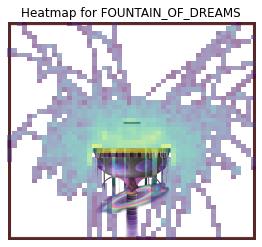

[figure not shown]

[figure not shown]

```python
stage_data = [[], [], [], [], [], []]

# Collect the position data on each stage
for row, data in games_df.iterrows():
    index = stage_index[data['stage']]
    stage_data[index].extend(data['frames'])

# Use bins of 50 to add some blur then plot the heatmap on the image of the stage
for stage in games_df['stage'].unique():
    game_df = pd.DataFrame(data = stage_data[stage_index[stage]], columns = ['x', 'y', 'stocks', 'percent', 'opponent_x', 'opponent_y', 'opponent_stocks', 'opponent_percent'])

    im = plt.imread(images[stage])
    heatmap, xedges, yedges = np.histogram2d(game_df['x'],game_df['y'], bins=50, density = True)
    extent = [xedges[0], xedges[-1], yedges[0], yedges[-1]]

    plt.title("Heatmap for " + stage)
    plt.imshow(im, extent = stage_dimensions[stage])
    plt.imshow(heatmap.T, extent=extent, origin='lower', norm=mpl.colors.LogNorm(), alpha = 0.5)
    plt.axis('off')
    plt.show()
```

We can see a lot of really interesting data here. Firstly we can see a clear preference to being in the center and as we move away from the center, characters spend less time there.

On every stage the most common place characters are is on the main part of the stage. This makes sense since this is often considered to be the safest place to be and a lot of the game revolves around trying to have control over this part of the stage. We can also see that people tend to spend the second most amount of time on the platforms which makes sense as those are useful both for combos and to try to escape combos. The only stage which doesn't seem to follow that is Fountain of Dreams. That stage seems to have a lot of action between the one platform in that image and the main part of the stage. However, Fountain of Dreams actually has 2 more platforms on the sides which aren't in this picture. However, these platforms move up and down randomly on random intervals and sometimes disappear so it would make sense for those general areas to have increased characters present rather than more pronounced lines like on the other stages.

We can also notice on each stage that right next to and slightly below the main platform of the stages there is an area of increased activity. This also makes sense since in Melee you can grab the corners of the main platform. This gives you a brief period of invincibility so many people will let go of the ledge and fall down a bit before jumping to grab the ledge again as a method of stalling. There also exist some advanced techniques from the ledge which require you to drop down first which may also explain the increased presence in this part of the stage.

One thing that surprised me was how empty Fountain of Dreams seemed to be compared to the other stages. It also seems like characters died off the bottom more often than on the other stages. Perhaps if less games were played on this stage compared to other stages this could be due to a few characters preferring to pick this stage and their playstyles causes more deaths on the bottom of the stage.

We can test this by viewing the plays on each stage and seeing all the matchups on Fountain of Dreams.

```python
stages = games_df['stage'].unique()
stage_plays = []
for stage in stages:
    stage_plays.append([stage, len(games_df[games_df.stage == stage])])
stage_plays_df = pd.DataFrame(data = stage_plays, columns = ['stage', 'plays'])
print(stage_plays_df.sort_values(by = ['plays'], ascending=False))
print("\n", games_df[games_df.stage == "FOUNTAIN_OF_DREAMS"][['char', 'opponent_char']])
```

```
                stage  plays
0         BATTLEFIELD     48
2      DREAM_LAND_N64     40
4     POKEMON_STADIUM     32
5        YOSHIS_STORY     30
1   FINAL_DESTINATION     26
3  FOUNTAIN_OF_DREAMS      8

                char   opponent_char
10              FOX         PIKACHU
11          PIKACHU             FOX
92   CAPTAIN_FALCON             FOX
93              FOX  CAPTAIN_FALCON
118           MARTH             FOX
119             FOX           MARTH
160             FOX  CAPTAIN_FALCON
161  CAPTAIN_FALCON             FOX
```

Here we can see that my explanation seems to be correct. Fountain of Dreams has significantly less plays than all the other stages. Also, in every match on Fountain of Dreams, fox is in the game. This implies that fox players tend to prefer this stage or players like to play against fox on this stage and that this may influence where either fox dies or where the fox player manages to kill their opponent.

## Heat Maps Before Deaths

Now that we have seen where characters are generally positioned during the match we want to see if there is any difference between the general heatmap and the heatmap before death. This will allow us to visually see if there is a differencein where characters are positioned when they die.

We do this by going through each game and marking down what frames a player has a lower stock count than on the previous frame. We then add the last frame if this player lost this game. We then append the previous 120 frames to the relevant list based on what stage we are on. Since slippi runs at 60 FPS, in 2 seconds there are 120 frames.

[figure not shown]

[figure not shown]

[figure not shown]

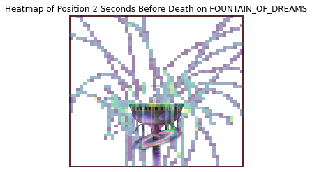

[figure not shown]

[figure not shown]

```python
stage_death_data = [[], [], [], [], [], []]

# Collect all the frames 2 seconds before death
for row, data in games_df.iterrows():
    index = stage_index[data['stage']]
    prev_stocks = 4
    death_frames = []
    frames = data['frames']

    # Find the frames with less stocks than the prev stock
    for i in range(len(frames)):
        if frames[i][2] != prev_stocks:
            prev_stocks = frames[i][2]
            death_frames.append(i - 1)

    # Add the last frame if this player lost
    if not data['win']:
        death_frames.append(len(frames) - 1)

    # Add the previous 120 frames from each death frame.
    for i in death_frames:
        stage_death_data[index].extend(data['frames'][i - 120:i])

# Use bins of 50 to add some blur then plot the heatmap on the image of the stage
for stage in games_df['stage'].unique():
    game_df = pd.DataFrame(data = stage_death_data[stage_index[stage]], columns = ['x', 'y', 'stocks', 'percent', 'opponent_x', 'opponent_y', 'opponent_stocks', 'opponent_percent'])

    im = plt.imread(images[stage])
    heatmap, xedges, yedges = np.histogram2d(game_df['x'],game_df['y'], bins=50, density = True)
    extent = [xedges[0], xedges[-1], yedges[0], yedges[-1]]

    plt.title("Heatmap of Position 2 Seconds Before Death on " + stage)
    plt.imshow(im, extent = stage_dimensions[stage])
    plt.imshow(heatmap.T, extent=extent, origin='lower', norm=mpl.colors.LogNorm(), alpha = 0.5)
    plt.axis('off')
    plt.show()
```

We can see a pretty clear difference between these heat maps and the general heatmaps we saw before. We can see that being in the center of the stage in the 2 seconds before death is a lot less common than in the rest of the game. We can also see that the areas near the ledges are commonly where people are before they die. There also seems to be an increased presence on platforms but it seems to be a fairly slightly difference.

## Testing Differences in the 120 Frames Before Death and General Position

We could see visually that there was a pretty clear difference between where characters were the 120 frames before death vs their general position. Here we will test that hypothesis. In order to test this we will see if there is a difference in the position between the general position and in the 120 frames before death.

Our Null Hypothesis is that there is no difference between position in the whole game and position in the 120 frames before death. Our Alternative Hypothesis is that there is a difference between position in the whole game and position in the 120 frames before death. We will be testing this for each stage. We will be using a p value of 0.05 to reject the null hypothesis.

```python
for stage in games_df['stage'].unique():
    general_data = stage_data[stage_index[stage]]
    death_data = stage_death_data[stage_index[stage]]
    general = []

    # Get the x and y value for each frame
    for frame in general_data:
        general.append([frame[0], frame[1]])

    death = []
    # Get the x and y value for each frame before death
    for frame in death_data:
        death.append([frame[0], frame[1]])

    print("2 Sample T test for", stage, ": ", stats.ttest_ind(general, death))
```

```
2 Sample T test for BATTLEFIELD :  Ttest_indResult(statistic=array([-36.03058101,  -2.65608036]), pvalue=array([6.69947593e-284, 7.90573928e-003]))
2 Sample T test for FINAL_DESTINATION :  Ttest_indResult(statistic=array([-36.32815485,   6.41307994]), pvalue=array([2.74707166e-288, 1.42834595e-010]))
2 Sample T test for DREAM_LAND_N64 :  Ttest_indResult(statistic=array([ 0.31791653, 18.4145499 ]), pvalue=array([7.50548397e-01, 1.06942549e-75]))
2 Sample T test for FOUNTAIN_OF_DREAMS :  Ttest_indResult(statistic=array([-5.68402755, -4.62480772]), pvalue=array([1.32025848e-08, 3.75545498e-06]))
2 Sample T test for POKEMON_STADIUM :  Ttest_indResult(statistic=array([  3.5914381 , -22.07998964]), pvalue=array([3.28906222e-004, 5.90099932e-108]))
2 Sample T test for YOSHIS_STORY :  Ttest_indResult(statistic=array([10.00003304,  1.30692064]), pvalue=array([1.53707374e-23, 1.91240714e-01]))
```

Here we can see that on Battlefield, Final Destination, Fountain of Dreams, Pokemon Stadium, and Yoshi's story we can reject the null hypothesis since the p value for the x values being different is below 0.05. We can also see that for Battlefield, Final Destination, Dream Land, Fountain of Dreams, and Pokemon Stadium we can reject the null hypothesis since the p value for the y values being different is below 0.05.

Interestingly the only stage where we can't reject the null hypothesis for x is Dream Land and for y it's Yoshi's Story. This may be because Dream Land is the widest stage so it may be that characters tend to die while trying to recover meaning they miss the ledge and fall down near the center of the stage. For Yoshi's story this is a stage with a low ceiling so it may be that characters are as likely to be killed off the top as they are on the bottom.

## Predicting Wins

As we say above there is a correlation between position and losing a stock in the next 2 seconds. Now let's test 2 models for predicting a win. The first one will just return the player who has more stocks and if that is tied then the player with a lower percent. The second will use a knn with both the percent and position in the case that the stocks are equal.

Since we have the most data on battlefield we will only be using that stage so our model doesn't have to worry about what stage it is and it is the stage with the most data.

In order to do this we first take each match on battlefield and randomly select 1 out of every 60 frames. We do this so that the knn doesn't "memorize" the data by having a bunch of points from the same game close to each other and making predictions based on that. For each of these frames we also keep track of if this player won.

We then split this data up into training and test data.

Then we create the model which just makes decisions based on stocks and percent. If this player has more stocks it returns true, if this player has less it returns false. If this player has equal stocks but less percent this model returns true, equal stocks but more percent this model returns false, and if both stocks and percent are equal it randomly selects true or false.

We then run our test data through this model and get the accuracy.

To train the KNN model we first have to filter the data since we only want to train it on cases where both players have the same amount of stocks. We also only need the player's x, y, percent, and opponent's percent. After filtering this data we fit the knn classifier using n = 5 since that is generally a good default number for knn models.

We then define the knn model. In the case that the stocks are unequal it behaves the same as the percent based model. In the case the stocks are equal we use the knn model we trained to predict the winner.

We then run our test data through the KNN model to get the accuracy.

```python
battlefield_df = games_df[games_df.stage == "BATTLEFIELD"]
model_data = []
model_pred = []

# Randomly get 1 out of every 60 frames for each game.
for row, data in battlefield_df.iterrows():
    samples = random.sample(data['frames'], int(len(data['frames']) / 60))
    for sample in samples:
        model_data.append(sample)
        model_pred.append(data['win'])

# Split the data into training and testing
X_train, X_test, y_train, y_test = model_selection.train_test_split(model_data, model_pred, test_size=0.3)

# Define the percent based model
def Percent(frame):
    if frame[2] > frame[6]:
        return True
    elif frame[6] > frame[2]:
        return False
    else:
        if frame[3] < frame[7]:
            return True
        elif frame[7] < frame[3]:
            return False
        else:
            return bool(random.getrandbits(1))

# Test the percent based model
y_pred_percent = []
for i in X_test:
    y_pred_percent.append(Percent(i))
print("Percent based accuracy: ", str(accuracy_score(y_test, y_pred_percent)))

# Filter the data to train the KNN
X_train_filtered = []
y_train_filtered = []
for i in range(len(X_train)):
    if X_train[i][2] == X_train[i][6]:
        X_train_filtered.append([X_train[i][0], X_train[i][1], X_train[i][3], X_train[i][7]])
        y_train_filtered.append(y_train[i])

# Fit the KNN model on the filtered data
neighbor = KNeighborsClassifier(n_neighbors=5)
neighbor.fit(X_train_filtered, y_train_filtered)

# Define the whole model
def KNN(frame):
    if frame[2] > frame[6]:
        return True
    elif frame[6] > frame[2]:
        return False
    else:
        return neighbor.predict([[frame[0], frame[1], frame[3], frame[7]]])[0]

# Test the KNN based model
y_pred_knn = []
for i in X_test:
    y_pred_knn.append(KNN(i))
print("KNN accuracy: ", str(accuracy_score(y_test, y_pred_knn)))
```

```
Percent based accuracy:  0.6909646442601484
KNN accuracy:  0.7206460061108686
```

We can see that the KNN model beat the percent based model by about 0.03. Both of these models beat random prediction by a very wide margin which we would expect to have an accuracy of 50%. This implies that stocks, percent, and position all have an impact on who wins the match.

I was pretty surprised that the accuracy of the KNN based model was significantly higher than the percent based model. I thought that it might end up being about equal or lower since most people will look a lot more at percentage than the character's position on the stage to determine who is winning.

## Conclusion

From the exploration of this data we have learned a lot of things. One thing I found really interesting was how pronounced the increased presence on the floor of the stage and the platforms was. While it makes sense since those are where you can run I thought it would be less pronounced due to the amount of time characters usually spend in the air. I also found it really interesting how you could see that players tend to spend a lot of time on the ledges of the stage. We could also see from the heatmap of position 2 seconds before death that often times being on the edge of the stage or slightly off the stage ended in the player dying in the next 2 seconds. We then showed that the distribution of positions 2 seconds before death was not the same as the distribution of positions during the entire match. We also found out that we could use the stocks, percent, and position to predict whether a player would win.

However, there are also still a lot of questions and further exploration. When we made the character matchup chart we can see that there is not enough data to be able to infer how characters generally do against each other. It would also be interesting to see win prediction done with a larger dataset so that we could include more variables. For example, the positioning of the opponent's character probably impacts the win percentage however adding too many variables for a limited dataset would likely decrease our accuracy. Some more variables to look at in the future could be the state variables which describe whether the player is running, walking, what attack they are using, etc.

I look forward to more tournaments publishing their replay files so that we can gain more insights into how players win or lose. It would also be very interesting to look at general community online play and potentially see how the differs from high level play. Perhaps that could also give players insights into what areas they should improve on in order to be competitive with top players.